# Visualising Brexit Votes with Leaflet and Cartogram

#### Voting results on a hexagon map

Prior to this point we have been working with the voting data and the shapefile separately, now it’s time to combine the voting data and the map:

```r
la_bng_new <- la_bng_new %>% merge(raw_votes, by.x = 'LAD12NM', by.y = 'Area')
la_bng_new$Result <- ifelse(la_bng_new$Remain > la_bng_new$Leave, 'Remain', 'Leave') %>% as.factor
```

Then we can plot the hexagon:

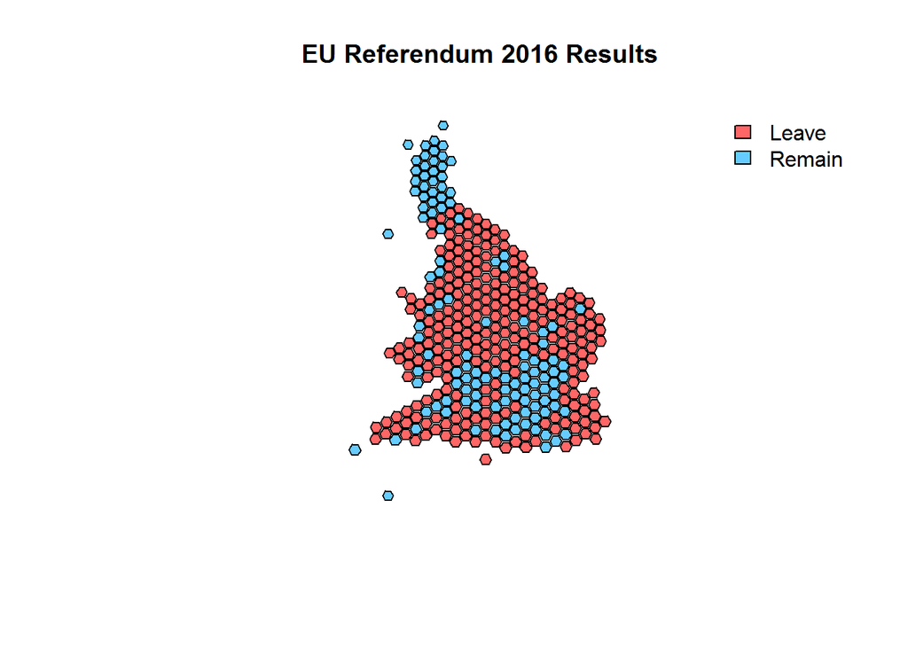

```r
cols <- c('#ff6666', '#66ccff')
plot(la_bng_new, col = cols[la_bng_new$Result], main = 'EU Referendum 2016 Results')
legend('topright', legend = c('Leave', 'Remain'), bty = 'n', fill = cols)
```

Let’s try rescaling the map using the `Valid_Votes` inside the votes data.

There are various options for creating a cartogram map, notably [`Rcartogram`](https://github.com/omegahat/Rcartogram) and [`getcartr`](https://github.com/chrisbrunsdon/getcartr) packages have been used together (e.g. Michael Höhle’s [nice post](http://staff.math.su.se/hoehle/blog/2016/10/10/cartograms.html)). The downside of those is that the installation process can be complicated (see [this Stack Overflow answer](http://stackoverflow.com/a/31632361/2708177) for a complete process). for a simple solution the `cartogram` package on CRAN is a good alternative:

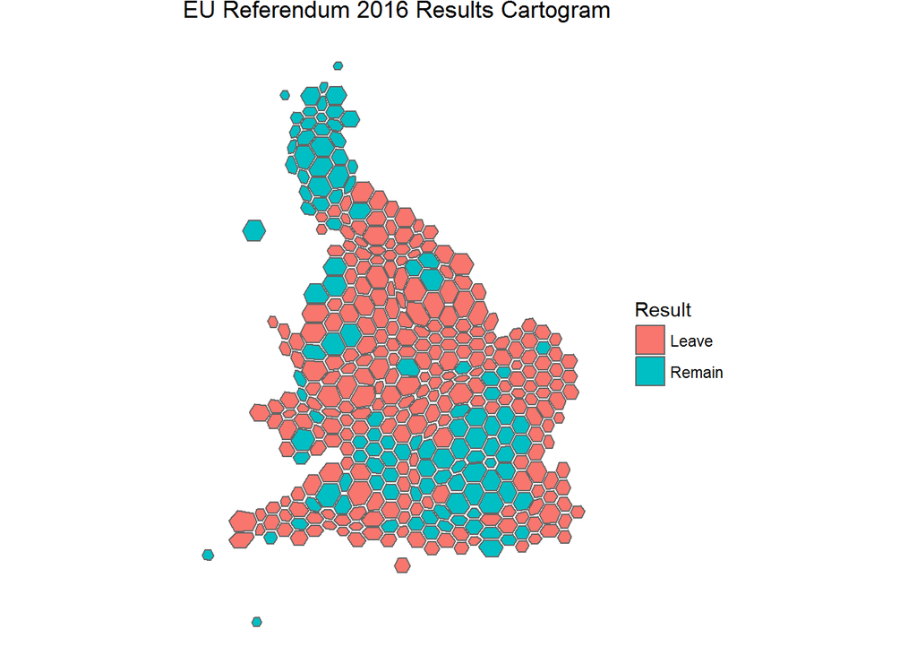

```r
# Plot cartogram
library(cartogram)
carto <- cartogram(la_bng_new, 'Valid_Votes')
carto_df <- carto %>% tidy(region = 'LAD12NM')
carto_df <- carto_df %>%
  left_join(
    data.frame(id = as.character(la_bng_new$LAD12NM),
               Result = as.factor(la_bng_new$Result),
               stringsAsFactors = F))

ggplot() + theme_bw() + theme_nothing(legend = TRUE) + coord_fixed() +
  geom_polygon(data = carto_df, colour = 'gray40',
               aes(x = long, y = lat, group = id,
                   fill = Result)) +
  ggtitle('EU Referendum 2016 Results Cartogram')
```

This makes slightly more sense, but there are still two issues:

1. The proportion of Leave and Remain varies across regions wildly:

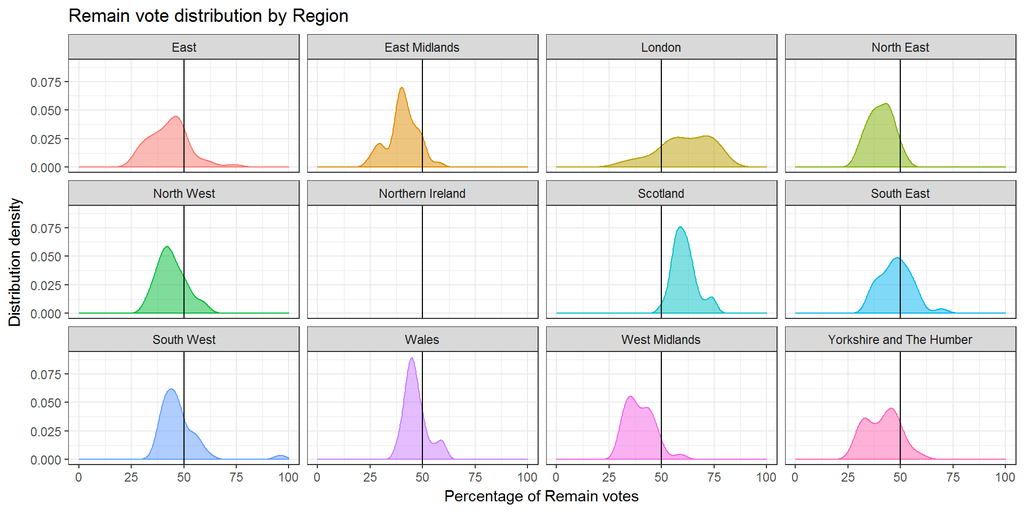

```r
pacman::p_load(ggplot2)
ggplot(data = raw_votes,
       aes(x = Pct_Remain, fill = Region, col = Region)) +
  geom_density(alpha = 0.5) + theme_bw() +
  xlim(0, 100) + ylim(0, 0.09) +
  geom_vline(aes(xintercept = 50)) +
  facet_wrap(~Region) + theme(legend.position="none") +
  xlab('Percentage of Remain votes') +
  ylab('Distribution density') +
  ggtitle('Remain vote distribution by Region')
```

*Note, for Northern Ireland there is only one data point (@ 55.8%), hence the invisible verticle line in the density graph.*  
Therefore we must not lose the information on the map. 2. aren’t you just dying to work out which area is which?

Let’s get straight down to `leaflet` to address all of the above.

### Plotting cartogram with `leaflet`

Before plotting the map we need to take care of a couple of things:

#### More dramatic scaling

The above cartogram looks fine, it probably represent the valide votes fairly accurately. But for aesthetic purposes, I think a more dramatic scaling would be more interesting, this means the difference of polygons are exaggerated and some areas are over shaddowing others in size, but that would make the visualisation more telling, and easier to grab attention, which is a major point of data visualisation. So instead of using `Valid_Votes` we use the square of it.

#### Information tag

Taking advantage of Javascript we can include much information dynamically, e.g. showing the votes when the mouse cursor hovers on the polygons. These need to be created as separate HTML tags.

#### Colouring for votes percentage

There is a wide range of votes percentage (% of Remain from 24% to 96%), This should be differentiated by colours. The last thing we need to take care off is a small tweak on the scaler for Gibraltar. Gibraltar being a British overseas territory (with a population of just over 30,000, located at the bottom of Spain) naturally voted overwhelmingly Remain (yes, that one with 96%). Allowing the outlier to be part of the colour palette would push everything close hence showing less disguishable colours, and for this reason, we are going to make the outlier value the same as the second highest (Lamberth at 79%, and by now you probably know where I stand on the [McCandless vs. Tufte debate](https://www.themediaflow.com/blog/making-great-infographics-the-data-vs-design-debate)).

```r
pacman::p_load(leaflet)
cols1 <- c("#ad0037", "#004080")
# Transforming the scaling factor Valid_Votes
la_bng_new$Valid_Votes_sq <- la_bng_new$Valid_Votes ^ 2
carto_x <- cartogram(la_bng_new, 'Valid_Votes_sq')

# Create vote percentage colour scale
carto_x$Pct_Remain_2 <- carto_x$Pct_Remain
carto_x$Pct_Remain_2[carto_x$LAD12NM == 'Gibraltar'] = carto_x$Pct_Remain_2[carto_x$LAD12NM == 'Lambeth']
carto_x$fill_op <- abs(carto_x$Pct_Remain_2 - 50) / max(abs(carto_x$Pct_Remain_2 - 50))

# Create the vote result HTML tag
labels2 <- sprintf(
  '<strong>%s</strong><br/>Remain: %s (%.0f%%)<br/>Leave: %s (%.0f%%)',
  carto$LAD12NM,
  prettyNum(carto$Remain, big.mark = ','), 100 * carto$Remain / carto$Valid_Votes,
  prettyNum(carto$Leave, big.mark = ','), 100 * carto$Leave / carto$Valid_Votes
) %>% lapply(htmltools::HTML)

# Leaflet CRS object for WGS84 projection
epsg4326 <- leafletCRS(
  crsClass = 'L.Proj.CRS',
  code = 'EPSG:4326',
  proj4def = '+init=epsg:4326 +proj=longlat +datum=WGS84 +no_defs +ellps=WGS84 +towgs84=0,0,0',
  resolutions = 2^(16:7))

pal <- colorFactor(
  palette = cols1,
  domain = carto_x$Result
)

# Leaflet map
leaflet(carto_x, options = leafletOptions(crs = epsg4326)) %>%
  addPolygons(
    color = "#444444", weight = 1, smoothFactor = 0.5,
    label = labels2,
    opacity = 1.0, fillOpacity = carto_x$fill_op, fillColor = cols1[as.factor(carto_x$Result)],
    highlightOptions = highlightOptions(color = "white", weight = 2, bringToFront = TRUE)) %>%
  addLegend("topright", pal = pal, values = ~Result,
    title = "Voting result",
    opacity = 1)
```

[interactive chart not shown]

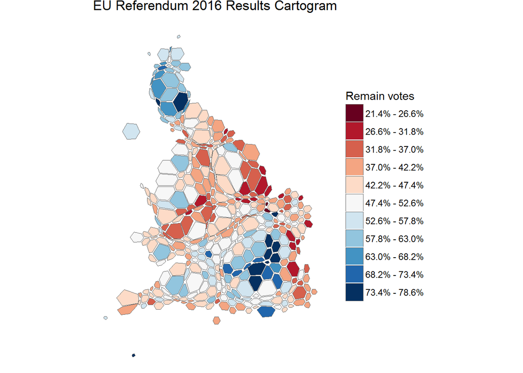

```r
carto_x_df <- carto_x %>% tidy(region = 'LAD12NM')
carto_x_df <- carto_x_df %>%
  left_join(
    data.frame(id = as.character(la_bng_new$LAD12NM),
               Result = as.factor(la_bng_new$Result),
               Pct_Remain = la_bng_new$Pct_Remain,
               stringsAsFactors = F))
# Rescaling Pct_Remain
carto_x_df$Pct_Remain_2 <- carto_x_df$Pct_Remain
carto_x_df$Pct_Remain_2[carto_x_df$id == 'Gibraltar'] <- carto_x_df$Pct_Remain_2[carto_x_df$id == 'Lambeth']

# Re-order the data frame so that legend on the map follow logical order
carto_x_df <- carto_x_df[order(carto_x_df$Pct_Remain_2), ]

# Create the banding of Remain percentage
col_vals <- carto_x_df$Pct_Remain_2
min_pct <- 50 - max(abs(col_vals - 50))
max_pct <- 50 + max(abs(col_vals - 50))
carto_x_df$pct_banded <- cut(col_vals, seq(min_pct, max_pct, (max_pct - min_pct) / 11))

# Make the legend labels prettier
pct_labs <- as.character(carto_x_df$pct_banded)
pct_labs <- substr(pct_labs, 2, nchar(pct_labs) - 1)
tmp <- sapply(pct_labs, function(x) strsplit(x, split = ','))
pct_labs <- sapply(tmp,
  function(x) paste0(
    formatC(as.numeric(x[1]), digits = 1, format = 'f'), '% - ',
    formatC(as.numeric(x[2]), digits = 1, format = 'f'), '%'))
carto_x_df$pct_banded <- as.factor(pct_labs)

ggplot(data = carto_x_df, aes(x = long, y = lat, group = id)) +
  theme_bw() + coord_fixed() +
  theme_nothing(legend = TRUE) +
  ggtitle('EU Referendum 2016 Results Cartogram') +
  geom_polygon(aes(fill = pct_banded), colour = 'gray40', size = 0.2) +
  scale_fill_brewer(
    name = 'Remain votes',
    type = 'div',
    palette = 'RdBu',
    breaks = carto_x_df$pct_banded,
    labels = carto_x_df$pct_banded)
```

### Other cartogram related packages

- [`topogRam`](https://github.com/pvictor/topogRam) - a `d3.js` based package